# Gaining Insights on Global Suicide

Eric Newcomer, Rachel Jung, Joonwoo Bae, Will Huang

1/29/2020

## Introduction

Suicide is a very serious issue that impacts millions across the world. According to the NIH, suicide is among the leading causes of death in the United States (https://www.nimh.nih.gov/health/statistics/suicide.shtml) and each year in the world, approximately one million people die from suicide (https://www.befrienders.org/suicide-statistics).

For our project, we chose to analyze suicide in the world using the [Suicide Rates Overview 1985 to 2016](https://www.kaggle.com/russellyates88/suicide-rates-overview-1985-to-2016) dataset. It was created by a Kaggle user who combined datasets (joining by time and place) from the United Nations Development Program, the World Bank, and the World Health Organization. The pulled-in data provides additional information about each country, including each country’s [human development index](http://hdr.undp.org/en/indicators/137506) and GDP statistics. Additionally, the dataset organizes suicide occurrences by year, sex, and age.

Through our data visualizations and other similiar analyses that focus on this data, we hope to spread awareness about the gravity of this issue and the enormous amount of lives that it affects, both directly and indirectly.

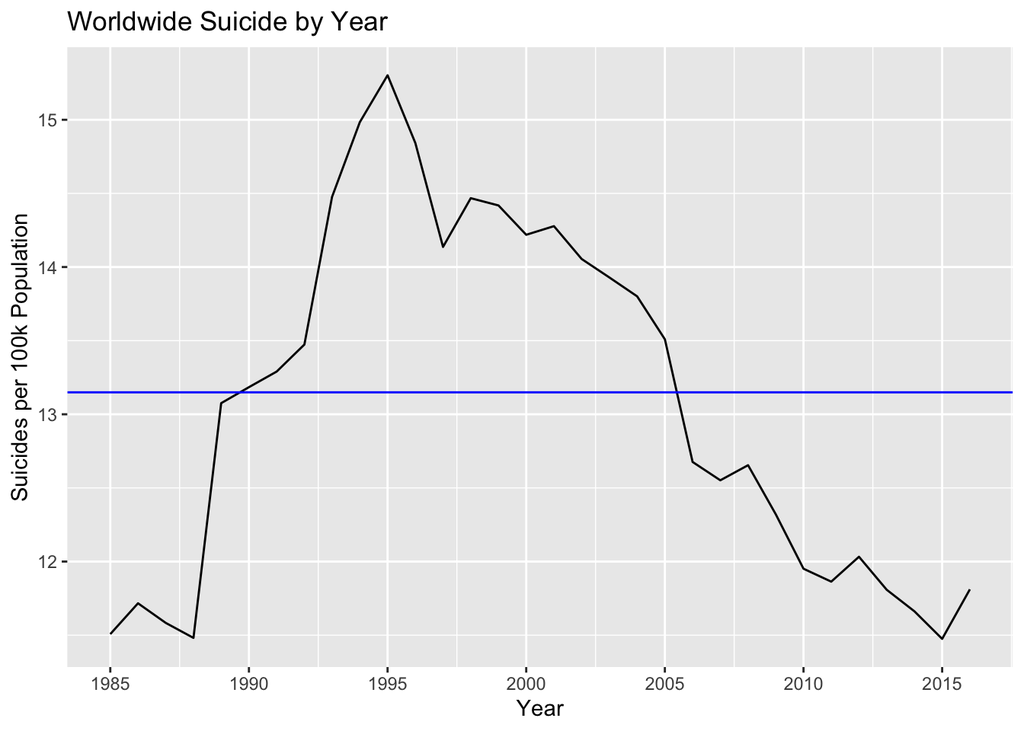

```r
world_average <- (sum(suicide$suicides_no) / sum(suicide$population)) * 100000


suicide %>%
  group_by(year) %>%
  summarise(
    sui_100k = (sum(suicides_no) / sum(population)) * 100000
  ) %>%
  ggplot(aes(x = year, y = sui_100k)) +
  geom_line() +
  geom_hline(yintercept = mean(world_average), color="blue") +
  scale_x_continuous(breaks = scales::pretty_breaks(n = 5)) +
  labs(title = "Worldwide Suicide by Year", x = "Year", y = "Suicides per 100k Population")
```

The above plot shows the mean global suicides per 100k population in every year from 1985 to 2016. From the plot, it can be seen that the average amount of suicides per 100k population is 13.1 deaths. It can also be seen that suicides reached a maximum of 15.3 deaths in 1995. Since 1995, there has been a general trend downward, showing that the averate amount of suicides per 100k population is decreasing globally.

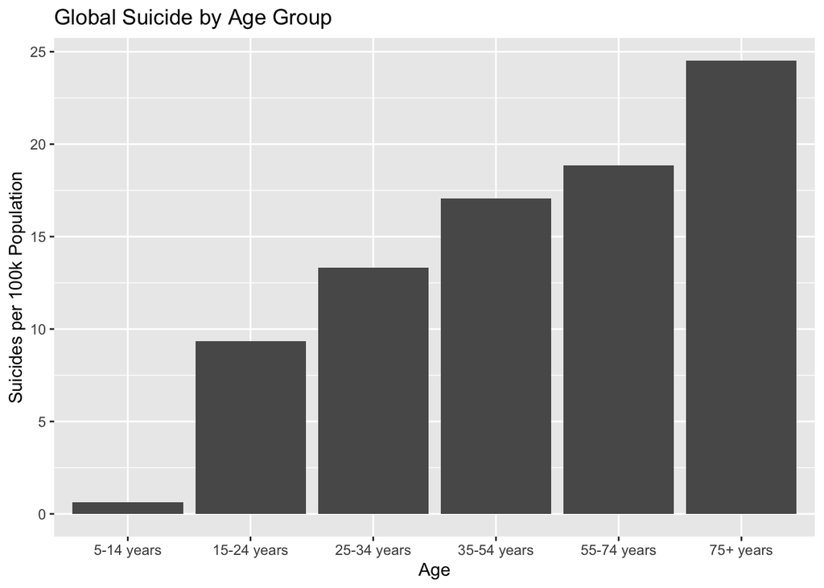

```r
suicide %>%
  group_by(age) %>%
  summarise(
    sui_100k = (sum(suicides_no) / sum(population)) * 100000
  ) %>%
  ggplot(aes(x = age, y = sui_100k)) +
  geom_bar(position="dodge", stat="identity") +
  labs(title = "Global Suicide by Age Group", x = "Age", y = "Suicides per 100k Population")
```

The above bar graph breaks down global suicides per 100k population by age group. As can be seen in the plot, suicide rate increases as age increases.

## Analysis

Come up with at least three interesting insights into the dataset. Insights can be something like “The Northeast has more private colleges than the West” or “Cereals on the first shelf tend to be more sugary”. Support each of your insights with at least one plot, with appropriate summary calculations, and with a clear discussion.

### Insight #1: Suicide Rates for Men and Women

To start, one key insight found in the suicide dataset is that since 2000 in the United States, higher suicides rates are seen among males compared to female suicide rates, shown among every age range. In fact, United States males who were 75+ in the past 20 years have a mean of almost 37.57 suicides per 100,000 people each year compared to U.S. females, who had 3.85 suicides per 100,000 people each. This drastic difference lessens generally as the age groups become younger, but we can still see the stark differences in suicides rates between men and women below when we look at the summary calculations.

```r
suicide %>%
  filter(country == "United States") %>%
  filter(year > 2000) %>%
  filter(sex == "male") %>%
  group_by(age) %>%
  summarize(suicide_per_100k = mean(`suicides/100k pop`)) %>%
  arrange(order(age))
```

```
## # A tibble: 6 x 2
##   age         suicide_per_100k
##   <fct>                  <dbl>
## 1 5-14 years             0.953
## 2 15-24 years           16.8
## 3 25-34 years           21.9
## 4 35-54 years           25.9
## 5 55-74 years           25.0
## 6 75+ years             37.6
```

```r
suicide %>%
  filter(country == "United States") %>%
  filter(year > 2000) %>%
  filter(sex == "female") %>%
  group_by(age) %>%
  summarize(suicide_per_100k = mean(`suicides/100k pop`)) %>%
  arrange(order(age))
```

```
## # A tibble: 6 x 2
##   age         suicide_per_100k
##   <fct>                  <dbl>
## 1 5-14 years             0.443
## 2 15-24 years            3.73
## 3 25-34 years            5.32
## 4 35-54 years            8.26
## 5 55-74 years            6.26
## 6 75+ years              3.85
```

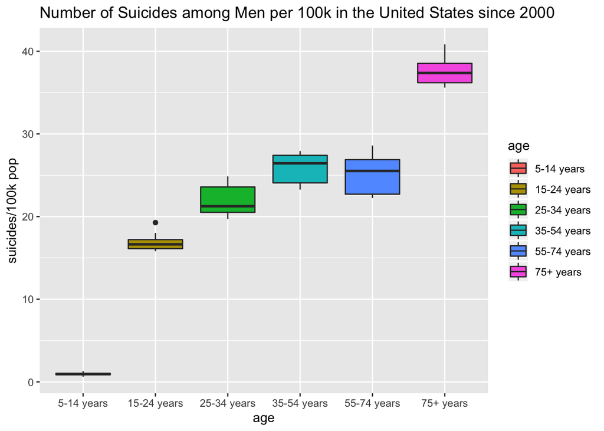

```r
suicide %>%
  filter(country == "United States") %>%
  filter(year > 2000) %>%
  filter(sex == "male") %>%
  ggplot(aes(y = `suicides/100k pop`, x = age, fill = age)) +
  geom_boxplot() +
  ggtitle("Number of Suicides among Men per 100k in the United States since 2000")
```

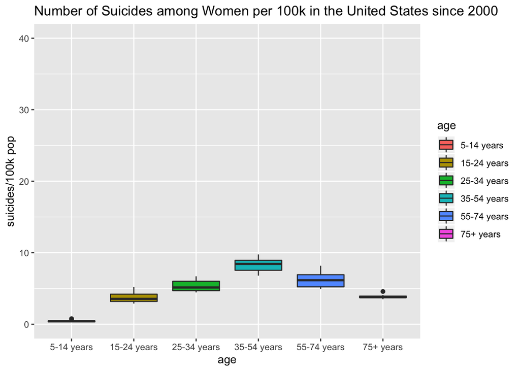

```r
suicide %>%
  filter(country == "United States") %>%
  filter(year > 2000) %>%
  filter(sex == "female") %>%
  ggplot(aes(y = `suicides/100k pop`, x = age, fill = age)) +
  geom_boxplot() +
  ylim(0,40) +
  ggtitle("Number of Suicides among Women per 100k in the United States since 2000")
```

To expand on this insight, we wanted to see if the occurrence of suicide was similar or different for men and women globally, from 1985 - 2016. To do this, we grouped the data by sex and piped it into a ggplot bar graph.

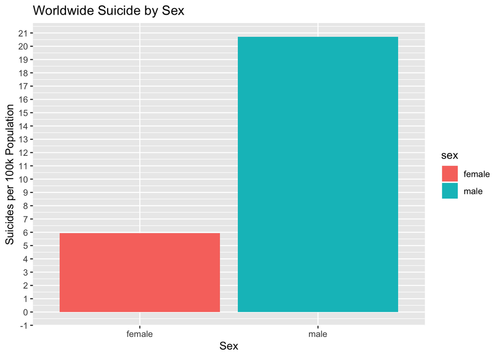

```r
# Suicide, men vs women
suicide %>%
  group_by(sex) %>%
  summarise(
    sui_100k = (sum(suicides_no) / sum(population)) * 100000
  ) %>%
  ggplot(aes(x = sex, y = sui_100k, fill = sex)) +
  geom_bar(stat="identity") +
  labs(title = "Worldwide Suicide by Sex", x = "Sex", y = "Suicides per 100k Population") +
  scale_y_continuous(breaks = scales::pretty_breaks(n = 20))
```

As can be seen from our data, we found that men commit suicide about **3.5 times more than women** globally, showing that the disparity in suicides between men and women continues continues to occur outside of the United States.

### Insight #2: Suicide Rates among younger generation

For our second insight, we wanted to determine which countries had the highest suicide rate (suicides per 100k population) among the younger generation, specifically those whose age is between 15 and 24 years.

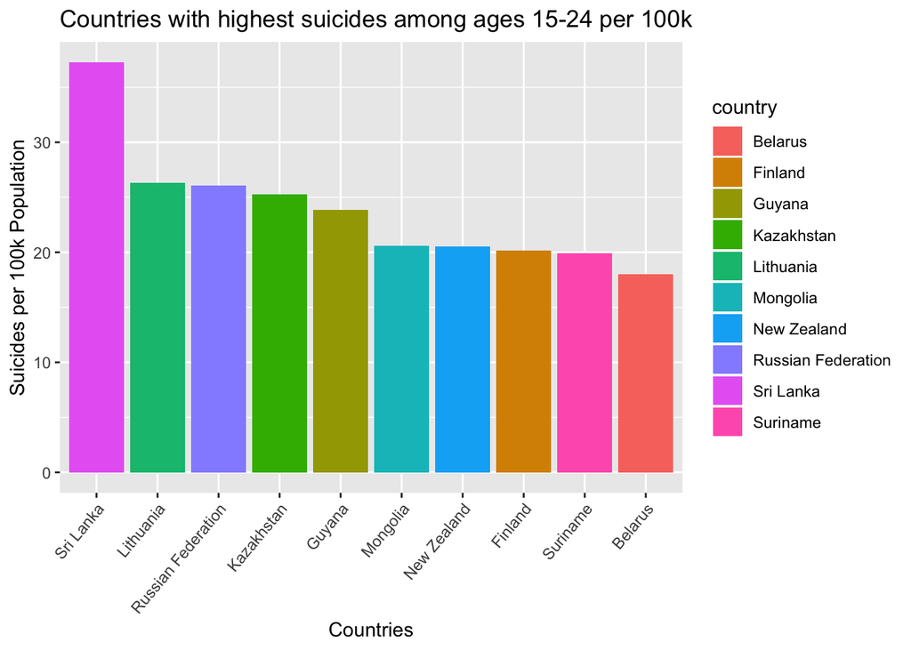

```r
# Highest suicide rates among 15-24 year olds
suicide %>%
  filter(age == "15-24 years") %>%
  group_by(country) %>%
  summarize(
    sui_100k= (sum(suicides_no) / sum(population)) * 100000
  ) %>%
  top_n(10) %>%
  ggplot(aes(x = reorder(country, -sui_100k), y = sui_100k, fill = country)) +
  geom_bar(stat="identity") +
  labs(title = "Countries with highest suicides among ages 15-24 per 100k", x = "Countries", y = "Suicides per 100k Population") +
  theme(axis.text.x = element_text(angle=50, hjust=1))
```

From our graph, we see that Sri Lanka is the country with the highest suicide rate among 15-24 year olds, with just over 37 deaths per 100k population. Sri Lanka’s suicide rate is significantly higher than the next highest suicide rate in Lithuania, by more than 10 deaths per 100k population. The rest of the countries are not as dissimilar. Knowing which countries have the highest suicide rate among a younger population is very important because it allows countries to take the appropriate steps and preventive measures to decrease the number of suicides among that population.

### Insight #3: Countries with Lowest Suicide Rates

For our third insight, we wanted to determine which countries had the lowest suicide rates. To investigate this, we grouped the dataset by country, calculated the suicide per capita, and took the lowest ten values.

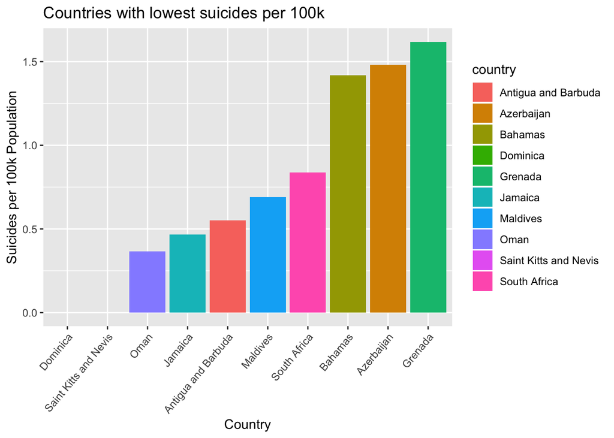

```r
# Lowest suicide rates in the dataset

suicide %>%
  group_by(country) %>%
  summarize(
    sui_100k= (sum(suicides_no) / sum(population)) * 100000,
  ) %>%
  top_n(-10) %>%
  ggplot(aes(x = reorder(country, sui_100k), y = sui_100k, fill = country)) +
  geom_bar(stat="identity") +
  labs(title = "Countries with lowest suicides per 100k", x = "Country", y = "Suicides per 100k Population") +
  theme(axis.text.x = element_text(angle=50, hjust=1))
```

From our graph, we see that Dominica and Saint Kitts and Nevis have the lowest suicide rates.